# Estimating Aquifer Health From Well Log Data on Bainbridge Island, WA

**Corey Christopherson**  
**DATA 512 - Final Project Report**  
**12/10/2019**

## Motivation

In March of 2013, the Environmental Protection Agency (EPA) designated the City of Bainbridge Island aquifer system as a sole source aquifer. According to the EPA, this designation identifies areas with an aquifer that provides more than 50% of the drinking water consumed in the area overlying the aquifer and, if contaminated, "would create a significant hazard to public health".

Since receiving this designation, the City of Bainbridge Island has experienced significant growth and development; and rumors about diminishing water supply, saltwater intrusion, and pollution are rampant.

As a Bainbridge Island resident and native, the health of the water supply is of critical importance to me. My intention with this project is to perform a statistical analysis of aquifer health by investigating well log data from the Washington State Department of Ecology. I will then send this analysis to members of the Bainbridge Island City Council to provide them with additional information as they attempt to craft policy.

## Background

There are several excellent resources available on the Bainbridge Island aquifer system. For this study I relied on three primary references:

- Conceptual Model and Numerical Simulation of the Groundwater-Flow System of Bainbridge Island, Washington (https://pubs.usgs.gov/sir/2011/5021/pdf/sir20115021.pdf)
- Support Document for Sole Source Aquifer Designation of the Bainbridge Island Aquifer System (https://semspub.epa.gov/work/10/100006730.pdf)
- Bainbridge Island Well Monitoring Program (https://www.bainbridgewa.gov/DocumentCenter/View/10883/2017-EWL-Report)

The earliest comprehensive analysis I found on the Bainbridge Island aquifer system was the *Conceptual Model and Numerical Simulation of the Groundwater-Flow System of Bainbridge Island, Washington* document produced by the US Geological Survey (USGS) in 2011. The purpose of this report was to "describe the hydrogeologic framework and groundwater flow in the study area and to document the development of a transient numerical groundwater-flow model". I used this very comprehensive document to check the technical details in the less-technical EPA Support Document described below.

The *Support Document for Sole Source Aquifer Designation of the Bainbridge Island Aquifer System* document was the primary source I used for this study because it is the document most commonly cited by both sides of the development debate. Specifically, I used the aquifer names and depth characteristics when classifying the well-to-aquifer mapping.

The final resource used for this study was the *Groundwater Monitoring Program Early Warning Level Assessment* paper produced by the City of Bainbridge Island in 2017. This report on the current state of the well monitoring program was used as a sanity check for the conclusions of this study.

## Research Questions

- RQ1: Has there been a statistically significant increase in the mean well depth on Bainbridge Island?
- RQ2: Is it possible to determine which of the three aquifers a well is tapped into?
- RQ3: Has there been a statistically significant increase in the mean well depth in any single aquifer?
- RQ4: Is it possible to cluster wells into specific regions or neighborhoods of Bainbridge Island?
- RQ5: Does this study support the findings of the Groundwater Monitoring Program

## Methodology

Simply stated, the methodology of this study was a comparison of the drilled well depth on Bainbridge Island over time to estimate the health of the island aquifer system.

The primary data source for this study was the Well Logs dataset from the Washington Department of Ecology. This data is available as a csv download from the Text Viewer Utility (described in the Data section below). This dataset contained the following critical fields:

1. The date the well was drilled
2. The location of the well
3. The depth of the drilled well

Other fields were present in the dataset and were retained where possible in case other research questions were developed during analysis.

The main processing requirement of this analysis was the conversion of the drilled well depth measurement to a depth value referenced from the Mean Sea Level (MSL). This conversion adjusted for the different elevations of the well heads and allows all wells to be compared using a common measurement. Additionally, the different aquifers are defined based on depths measured from MSL, so the well-aquifer mapping in RQ2 required well depths as measured from MSL. The Open-API resource (described in the data section below) was used to determine the elevation at the recorded latitude and longitude coordinated for each well head. However, the raw well locations were geolocated according to the Washington State Plane Coordinate System instead of the traditional latitude and longitude. This resulted in all wells being geolocated to the center of a 40-acre square which was far less accuracy than was desired. Despite this limitation, the coordinates for each well were translated into latitude and longitude values with the NGS Coordinate Conversion and Transformation Tool (NCAT) API from the National Oceanic and Atmospheric Administration (NOAA). In addition to enabling the elevation of each well location to be determined, this conversion also enabled the wells to be mapped and visually analyzed using Tableau software.

With the well logs data gathered, cleaned, and joined with the correct lat-longs and elevation values; it was now possible to evaluate RQ1. This was accomplished by performing a simple ordinary least-squares regression of well depth on the well completion date. The slope of this regression line was then compared against the null hypothesis that the regression coefficient is zero with a 95% confidence interval. After evaluating RQ1, an attempt was made to address RQ2 and RQ3 by determining which aquifer each well was drawing from based on the recorded well depth. The depth bands for each aquifer are described in the EPA Support Document and shown in the diagram below

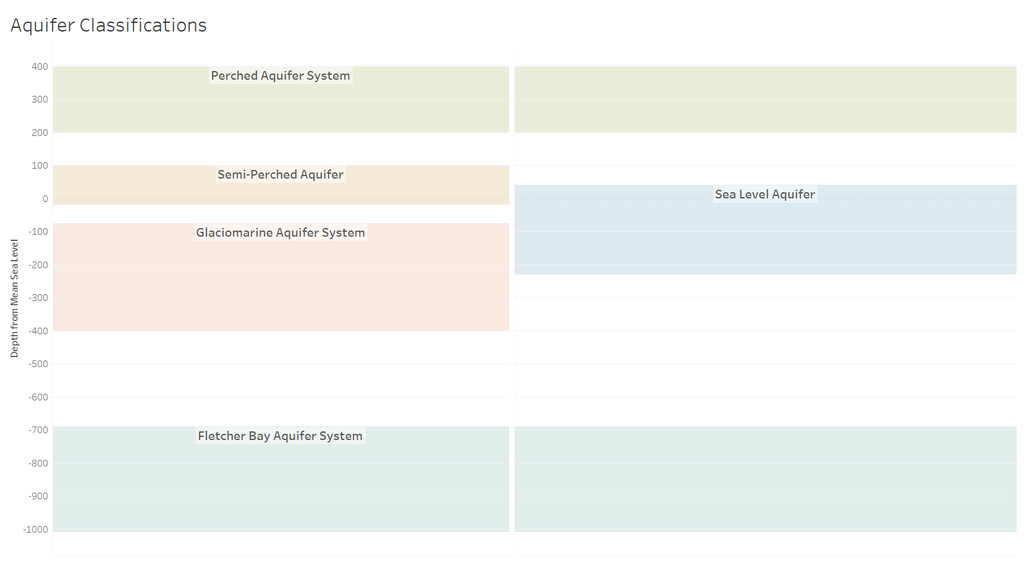

Because no labeled well data mapping wells to aquifers was available, it was necessary to use the unsupervised k-means clustering algorithm with k=5 for the five different major aquifers identified in the EPA support document. Once each well was mapped to an individual aquifer, the statistical analysis from RQ1 was repeated for each aquifer class. Finally, the results from this analysis were compared to the results of the aforementioned 2017 COBI Well Monitoring Program report.

NOTE: Because of the well location inaccuracy described previously, it was not possible to perform the neighborhood classification from RQ4.

```python
%%html
<style>
  table {margin-left: 0 !important;}
</style>
```

## Data Collection

The following section summarizes the data collection and cleaning process used for this study. The full procedure is recorded in the hcds-final-project-data-exploration.ipynb Jupyter Notebook located in the repo.

First, the data for this analysis was downloaded from the Washington State Department of Ecology using the Text Search Utility (https://fortress.wa.gov/ecy/wellconstruction/map/WCLSWebMap/TextSearch.aspx) as a csv (ed0c1eae-6b80-41dc-9424-0ccc1aa157c5_11052019.csv). Because this is public data no license was required. However, the terms of use (DISCLAMER.pdf) clearly state that the DOE makes no claim to the accuracy of the data, is not liable for any use or misuse of the data, and that state law prevents private citizen names and addresses from being used for solicitation or commercial purposes. Because the well owner name was not required for this study, the well_owner_nm field was removed from the raw data in an attempt to protect individual identities.

The required fields were then determined by referencing the well_log_datadictionary.pdf file included in each download.

| Name | Description |
| --- | --- |
| well_log_id | Unique well ID |
| well_depth_qt | Depth of well in feet |
| well_diameter_qt | Diameter of well in feet |
| well_comp_dt | Well completion date |
| well_type_cd | Well type code |
| ST_PLANE_XCOORD_NR | Well horizontal geographic coordinate value, WA State Plane Coordinate System |
| ST_PLANE_YCOORD_NR | Well vertical geographic coordinate value, WA State Plane Coordinate System |

Next, the following filtering steps were executed:

1. Dropped all records for wells with a well type code not equal to 'W' (Water)
2. Dropped records with NULL or missing values for the well_depth_qt, well_comp_dt, ST_PLANE_XCOORD_NR, ST_PLANE_YCOORD_NR fields

The data was then visualized in Tableau to identify any potential issues with the data. It appeared that data prior to 1973 was incomplete, so all records before 1973 were removed.

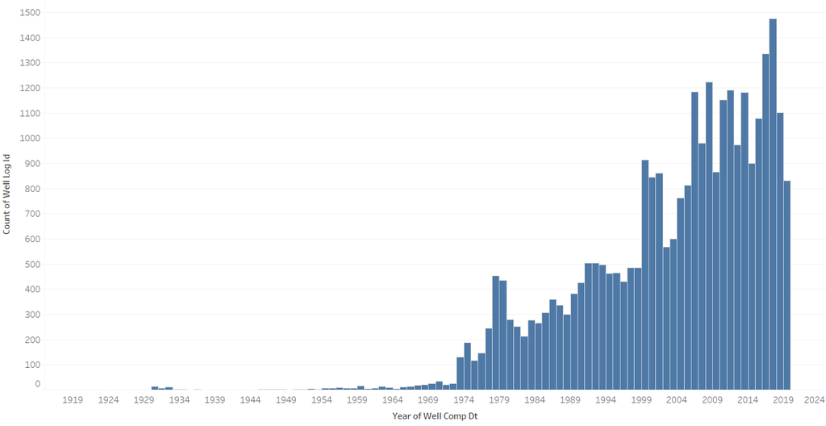

With the initial data cleaning complete, the well locations in lat-long were determined using the NGS Coordinate Conversion and Transformation Tool (NCAT) API from the National Oceanic and Atmospheric Administration (NOAA). Nine well logs did not return data and were removed. The data from this service is licensed in the public domain with some disclaimers for use noted in the NOAA Disclaimers page (https://www.ngs.noaa.gov/disclaimer.html). This data was then output (well_data_lat_long_kitsap_county.csv) and displayed visually in Tableau.

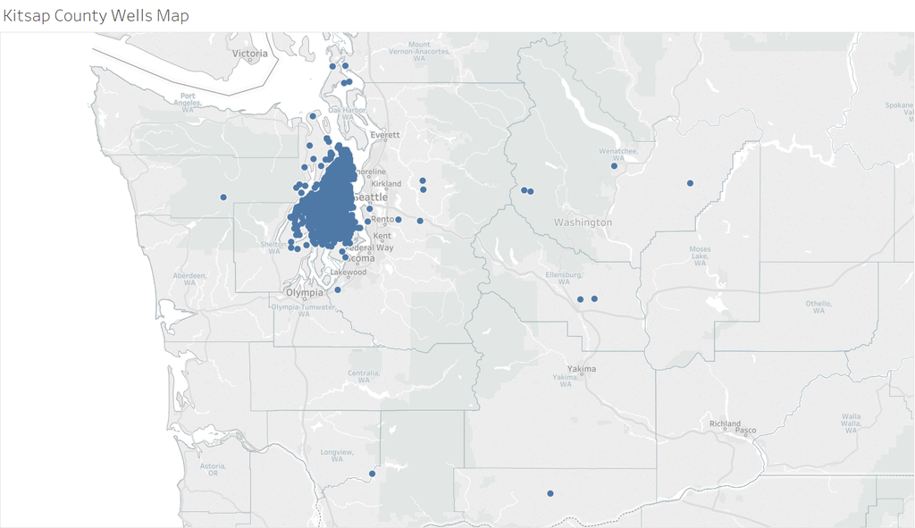

Next, all Bainbridge Island wells were manually selected and the underlying data was downloaded (well_data_lat_long_bainbridge_island.csv). This step removed all well logs that were not located on Bainbridge Island from the analysis.

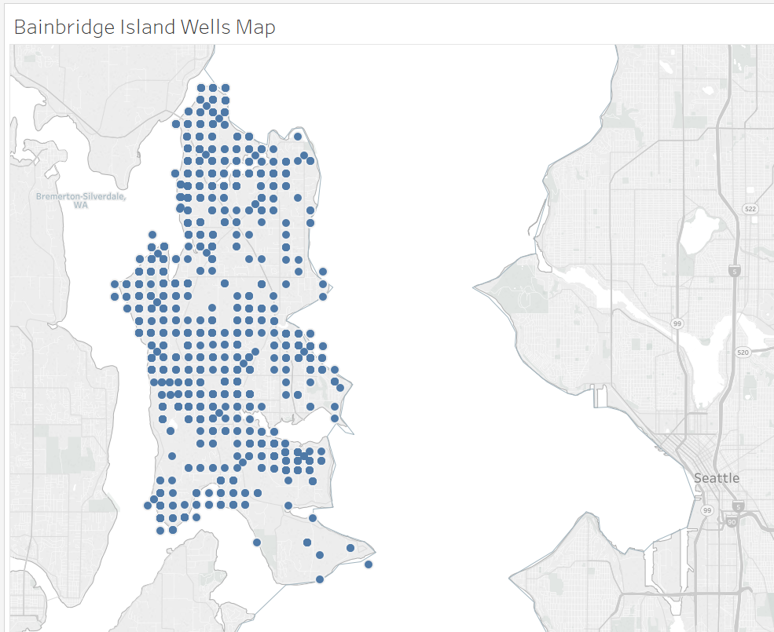

The approximate elevation of each well head was then determined with the Open-Elevation API (https://open-elevation.com/) licensed under GPLv2 (https://github.com/Jorl17/open-elevation/blob/master/license.md). Unfortunately, the API was not responding to requests because of funding issues (as noted here: https://github.com/Jorl17/open-elevation/issues/29). This limitation was overcome by breaking the lat-longs into blocs of 100 and pasting the URL directly into the Chrome search box. This returned the JSON response in text form which could them be copied into separate txt files, read into the notebook, and analyzed. Once each elevation was converted from meters to feet and joined to the main data frame, a new field was added for the well depth in reference to Mean Sea Level (MSL). This data was then output to a csv (well_data_bainbridge_island.csv) so that wells with a depth or elevation of zero could be examined in Tableau. The map of zero-depth and zero-elevation wells is shown below

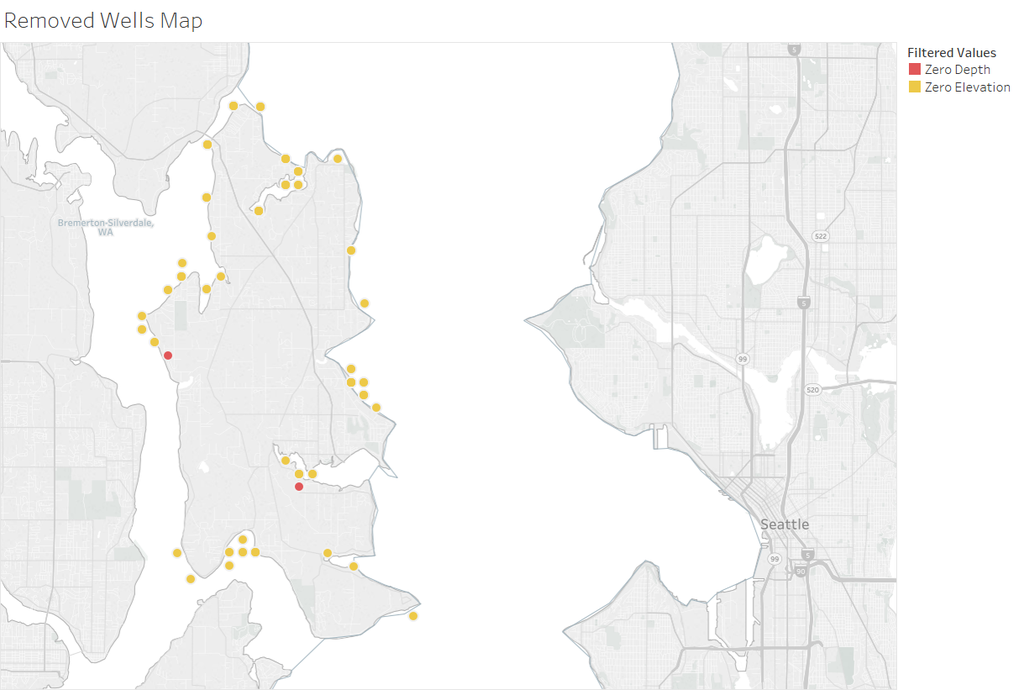

The two locations with zero well depth were removed because a well with zero depth does not make sense. Additionally, all of the zero-elevation records were confirmed to be at an elevation of zero and so were retained in the final data.

Next, a dashboard was created to investigate the well logs data over time as shown below. The trend in the number of wells drilled on Bainbridge Island annually were plotted in the left pane while the well depth of each well_id was plotted in the right plane. This allowed individual years to be investigated for potential issues.

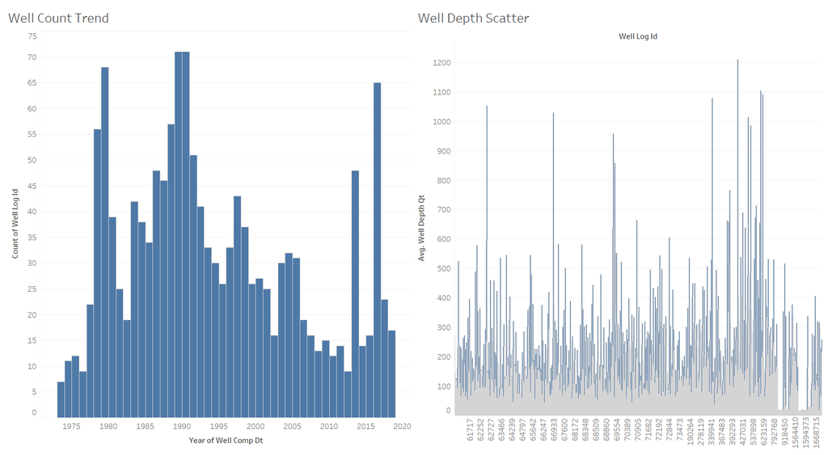

The unusually high spikes of 2013 and 2016 revealed a large number of wells with consecutive well_log_ids at the exact same depth.

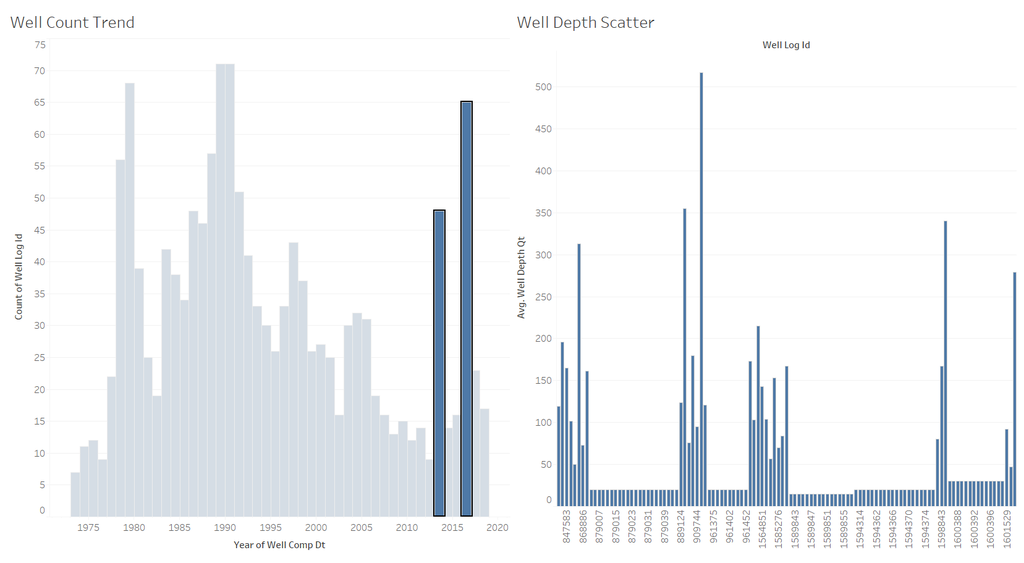

Further exploration revealed that these wells were also in the same location. Even if these wells were legitimate (which is highly unlikely) they represent an oversampling of that particular location in time. Because of this finding, multiple wells drilled on the same date, in the same location, and to the exact same depth were reduced to a single record.

This completed the data collection and cleaning process. The final study data was output to the well_data_bainbridge_island_final.csv csv file.

## Data Analysis

The following section summarizes the data analysis process used for this study. The full procedure is recorded in the hcds-final-project-data-analysis.ipynb Jupyter Notebook located in the repo.

The data cleaning process is summarized above and described in detail in the hcds-final-project-data-exploration.ipynb Jupyter Notebook. The resulting file from this process is the well_data_bainbridge_island_final.csv file and contains the following fields

| Name | Description |
| --- | --- |
| Well Log Id | Unique well ID |
| Well Comp Dt | Well completion date |
| Year | Well completion year |
| Well Depth Qt | Depth of well in feet |
| Well Diameter Qt | Diameter of well in feet |
| Well Depth | Depth of well in feet as measured from mean sea level (MSL) |
| elevation | Elevation of well location from the Open-Elevation API in meters |
| elevation (ft) | Elevation of well location from the Open-Elevation API in feet |
| St Plane Xcoord Nr | Well horizontal geographic coordinate value, WA State Plane Coordinate System |
| St Plane Ycoord Nr | Well vertical geographic coordinate value, WA State Plane Coordinate System |
| latitude | Well latitude from the NGS Coordinate Conversion and Transformation Tool (NCAT) API |
| longitude | Well longitude from the NGS Coordinate Conversion and Transformation Tool (NCAT) API |

RQ1 was investigated in Tableau by plotting the well depth versus the well completion date and examining the properties of the best fit linear trend line.

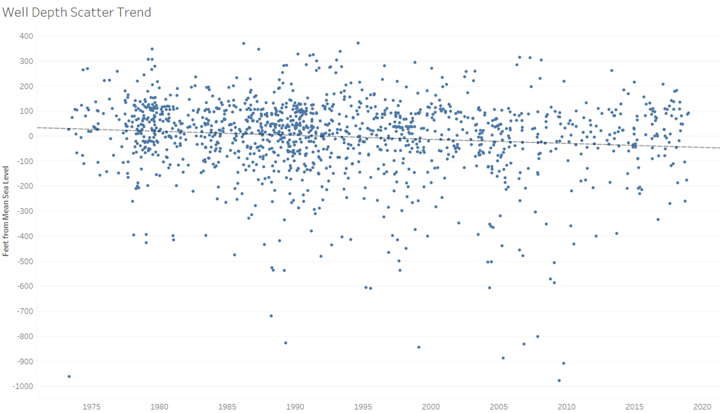

The trendline had the following properties

- Coefficient: -0.0044
- R-Squared: 0.013
- P-Value: < 0.0001

The above results show that the null hypothesis that there has been no change in mean well depth since 1973 is rejected.

RQ2 was then investigated by using the k-means classifier in the scikit-learn Python package. The number of clusters was set to _n*init=5* for each of the five aquifers identified in the EPA Support Document. The well trend scatter colorized by aquifer classification and overlaid on the aquifer classifications is shown below

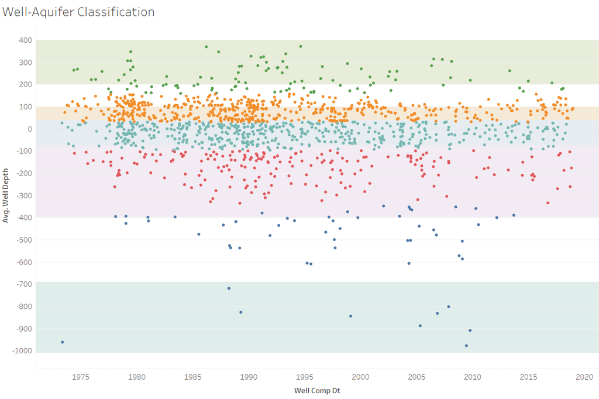

The allocation of individual wells looks reasonable, so RQ2 is answered in the affirmative.

Finally, RQ3 was investigated by repeating the analysis used in RQ1 by plotting the well depth versus the well completion date for each aquifer classification and examining the properties of the best fit linear trend line.

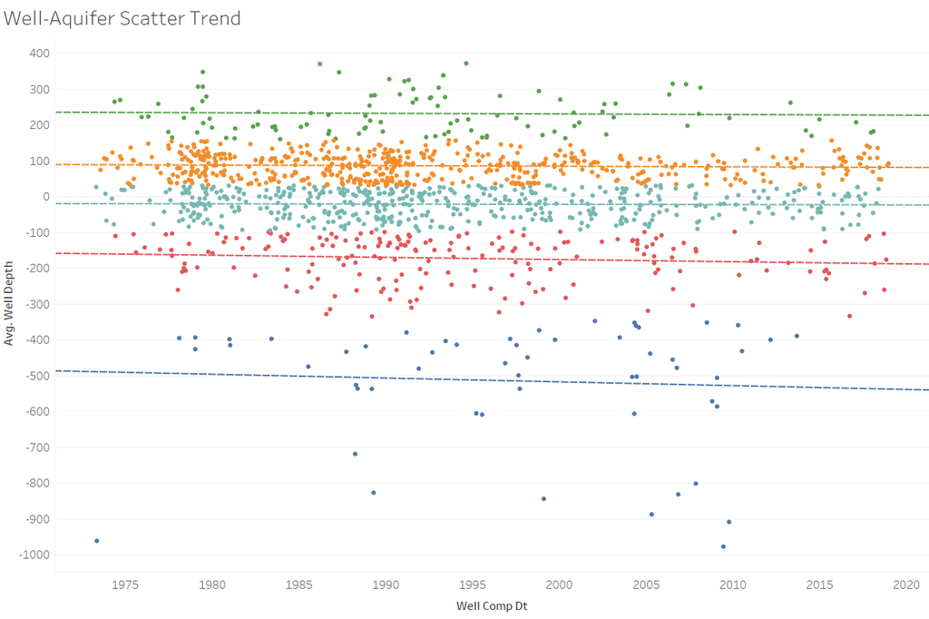

| Aquifer | Coefficient | R-Squared | P-Value |
| --- | --- | --- | --- |
| *Perched Aquifer System (green)* | -0.00046 | 0.001 | 0.736 |
| *Semi-Perched Aquifer (orange)* | -0.00045 | 0.003 | 0.192 |
| *Sea-Level Aquifer (teal)* | -0.00020 | 0.0005 | 0.620 |
| *Glaciomarine Aquifer System (red)* | -0.00166 | 0.012 | 0.139 |
| *Fletcher Bay Aquifer System (blue)* | -0.00290 | 0.004 | 0.646 |

The above results show that the null hypothesis that there has been no change in mean well depth since 1973 for any aquifer cannot be rejected.

## Findings

The findings for each of the research questions investigated are summarized below.

**RQ1: Has there been a statistically significant increase in the mean well depth on Bainbridge Island?**

Yes, there is a statistically significant increase in the mean well depth on Bainbridge Island since 1973

**RQ2: Is it possible to determine which of the three aquifers a well is tapped into?**

Yes, the well-to-aquifer classification was successfully made with a k-means classifier with n=5. However, since three of the aquifers overlap, and there are gaps in the EPA aquifer depth bands some additional information is likely required to improve these classifications.

**RQ3: Has there been a statistically significant increase in the mean well depth in any single aquifer?**

No, this analysis did not find a statistically significant increase in the mean well depth for any Bainbridge Island aquifer

**RQ4: Is it possible to cluster wells into specific regions or neighborhoods of Bainbridge Island?**

This question was abandoned because of the inaccuracy in well location data.

**RQ5: Does this study support the findings of the Groundwater Monitoring Program**

The most recent report from the Groundwater Monitoring Program did not find a significant reduction in the water level for any of the monitoring wells over the last ten years. However, several wells were identified as having a possible reduction in water levels and placed on a watch list. This report then concurs with the findings of this analysis. It's possible that aquifer levels on Bainbridge Island are dropping, but the reduction is not yet significant enough to be easily detected.

## Implications

The intent of this analysis was to provide additional clarity to the ongoing debate about water availability on Bainbridge Island and the implications for development.

Unfortunately, the results showed some measure of increased well depth, and therefore, potential but inconclusive evidence for dropping aquifer levels. Instead of strengthening one side of the debate or the other, this study provides further strength to the position that we may have a problem with water on Bainbridge Island but cannot be sure.

My future work on this project will be an attempt to increase the location resolution of each well record. This will improve the accuracy of the well depth from MSL metric as well as the geolocation of each well. These two factors combined will enable neighborhood classification and improve the well-to-aquifer mapping which hopefully, leads to more statistically significant results.

## Reflections

Had I been asked to perform this study before taking DATA 512, the result would have been very different from start to finish.

Beginning with data collection, I had never considered the licensing requirements or personally identifiable information associated with a dataset. These human-centered concerns not only show respect for the creators of a given dataset and the individuals identifiable within; but it also lends weight to my end product by demonstrating awareness and responsibility of industry best practices

Human-centered considerations have also changed my process of data exploration and cleaning by emphasizing the importance of reproducibility. I found that meticulously recording each step of my process made it much easier to remember what I had done when writing my final paper. I also found that the process of record keeping led me to much clearer thinking about a given set of problems and the justifications used for each decision.

Finally, the presentation and discussion of final results were the most impacted by human-centered considerations. Specifically, my visualizations were much better than they would have been otherwise because keeping in mind my intended non-technical audience forced me to put in the extra work required to communicate concepts clearly instead of lazily inserting some Python output into my workbook and relying on my audience to get the intended message.

I am very confident that the material and projects covered in this course have made me a much better engineer and data scientist.